# Model Performance Dashboard

## Version Control

Model trained + validated on data up to: 21Nov23

Report run on: 18Dec23

## Background:

### Summary

The model is a multinomial log-linear model trained to classify probabilities of three outcomes: home-team win, away-team-win or tie.

### Feature Importance

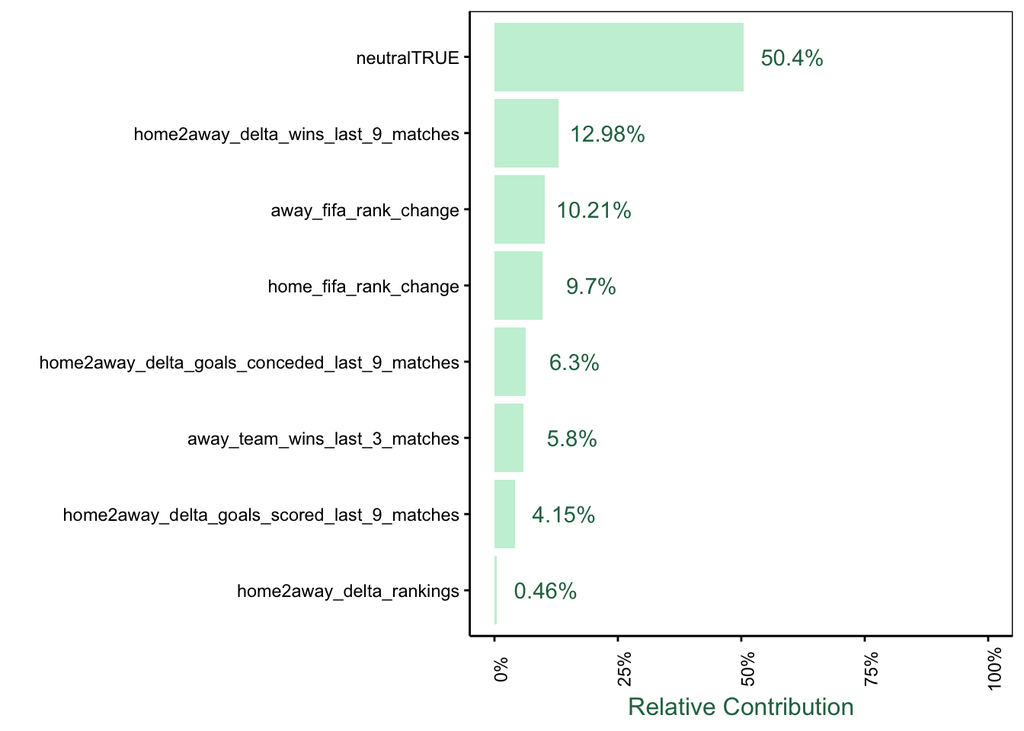

Almost 50% of prediction is driven by a single outcome (whether match was played on neutral grounds).

This relationship is intuitive, however too much contribution for a single variable. Will be investigated.

### Calibration & Sensitivity

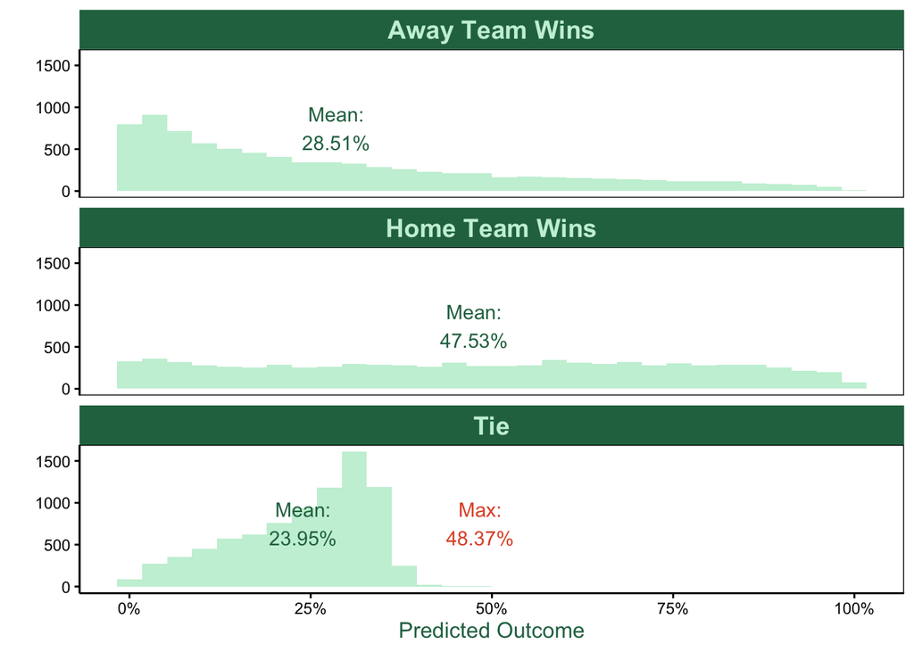

As per actuals, the predicted values average to outcomes roughly in the order of 50%-25%-25% for Home, Away and Tie respectively.

In terms of discrimination, both Home and Away classification models can produce outcomes with extremely high (>99%) or low (<1%) probabilities. The Tie classification model struggles to produce many high probabilities - implying that a tie is rarely the most likely outcome. This is also observed in exploratory data analysis, where very few variables are found to be strongly correlated with tie outcomes - and model performance, where false negative rate is high.

## Confusion Matrix

| prediction | away win | home win | tie |
| --- | --- | --- | --- |
| predicted away win | 747 | 146 | 277 |
| predicted home win | 251 | 1,497 | 526 |
| predicted tie | 41 | 39 | 56 |

## Sub-model Performance

### Home-win

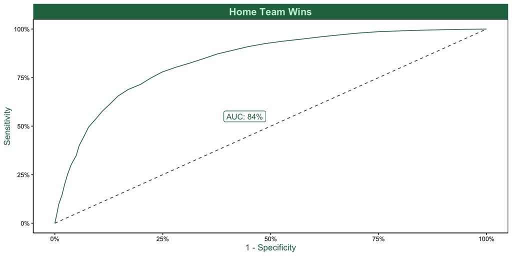

### Away-win

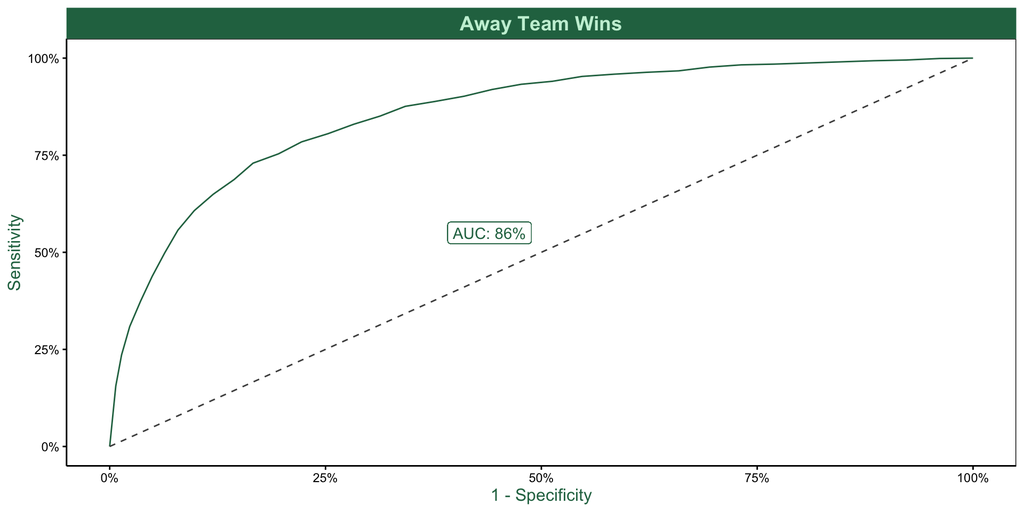

### Tie

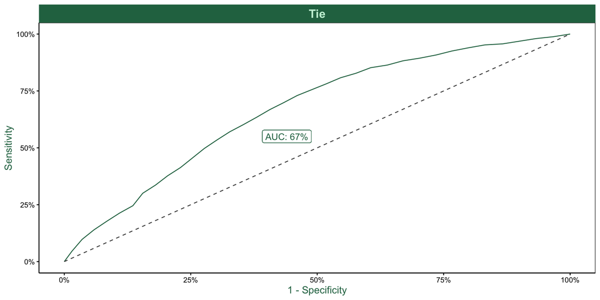